# Titanic dataset

Konstantinos

2017-09-17

# 1 Intro

```r
require(ggplot2)
require(RColorBrewer)
require(ggthemes)
require(dplyr)
library(xtable)
library(Amelia)
library(reshape2)
require(andrews)
require(tidyr)
require(GGally)
require(scales)
require(ggExtra)

# require(grid) for multiplot function
multiplot <- function(..., plotlist=NULL, file, cols=1, layout=NULL) {
  library(grid)

  # Make a list from the ... arguments and plotlist
  plots <- c(list(...), plotlist)

  numPlots = length(plots)

  # If layout is NULL, then use 'cols' to determine layout
  if (is.null(layout)) {
    # Make the panel
    # ncol: Number of columns of plots
    # nrow: Number of rows needed, calculated from # of cols
    layout <- matrix(seq(1, cols * ceiling(numPlots/cols)),
                    ncol = cols, nrow = ceiling(numPlots/cols))
  }

 if (numPlots==1) {
    print(plots[[1]])

  } else {
    # Set up the page
    grid.newpage()
    pushViewport(viewport(layout = grid.layout(nrow(layout), ncol(layout))))

    # Make each plot, in the correct location
    for (i in 1:numPlots) {
      # Get the i,j matrix positions of the regions that contain this subplot
      matchidx <- as.data.frame(which(layout == i, arr.ind = TRUE))

      print(plots[[i]], vp = viewport(layout.pos.row = matchidx$row,
                                      layout.pos.col = matchidx$col))
    }
  }
}
```

# 2 Read dataset - Basic exploration

```r
data = read.csv("train.csv")
dim(data)  ## rows and variables of the dataset
```

```
## [1] 891  12
```

```r
str(data)  ## structure of the data
```

```
## 'data.frame':    891 obs. of  12 variables:
##  $ PassengerId: int  1 2 3 4 5 6 7 8 9 10 ...
##  $ Survived   : int  0 1 1 1 0 0 0 0 1 1 ...
##  $ Pclass     : int  3 1 3 1 3 3 1 3 3 2 ...
##  $ Name       : Factor w/ 891 levels "Abbing, Mr. Anthony",..: 109 191 358 277 16 559 520 629 417 581 ...
##  $ Sex        : Factor w/ 2 levels "female","male": 2 1 1 1 2 2 2 2 1 1 ...
##  $ Age        : num  22 38 26 35 35 NA 54 2 27 14 ...
##  $ SibSp      : int  1 1 0 1 0 0 0 3 0 1 ...
##  $ Parch      : int  0 0 0 0 0 0 0 1 2 0 ...
##  $ Ticket     : Factor w/ 681 levels "110152","110413",..: 524 597 670 50 473 276 86 396 345 133 ...
##  $ Fare       : num  7.25 71.28 7.92 53.1 8.05 ...
##  $ Cabin      : Factor w/ 148 levels "","A10","A14",..: 1 83 1 57 1 1 131 1 1 1 ...
##  $ Embarked   : Factor w/ 4 levels "","C","Q","S": 4 2 4 4 4 3 4 4 4 2 ...
```

```r
data
```

| PassengerId | Survived | Pclass | Name | Sex | Age | SibSp | Parch | Ticket | Fare | Cabin | Embarked |
| --- | --- | --- | --- | --- | --- | --- | --- | --- | --- | --- | --- |
| 1 | 0 | 3 | Braund, Mr. Owen Harris | male | 22.00 | 1 | 0 | A/5 21171 | 7.2500 |  | S |
| 2 | 1 | 1 | Cumings, Mrs. John Bradley (Florence Briggs Thayer) | female | 38.00 | 1 | 0 | PC 17599 | 71.2833 | C85 | C |
| 3 | 1 | 3 | Heikkinen, Miss. Laina | female | 26.00 | 0 | 0 | STON/O2. 3101282 | 7.9250 |  | S |
| 4 | 1 | 1 | Futrelle, Mrs. Jacques Heath (Lily May Peel) | female | 35.00 | 1 | 0 | 113803 | 53.1000 | C123 | S |
| 5 | 0 | 3 | Allen, Mr. William Henry | male | 35.00 | 0 | 0 | 373450 | 8.0500 |  | S |
| 6 | 0 | 3 | Moran, Mr. James | male | NA | 0 | 0 | 330877 | 8.4583 |  | Q |
| 7 | 0 | 1 | McCarthy, Mr. Timothy J | male | 54.00 | 0 | 0 | 17463 | 51.8625 | E46 | S |
| 8 | 0 | 3 | Palsson, Master. Gosta Leonard | male | 2.00 | 3 | 1 | 349909 | 21.0750 |  | S |
| 9 | 1 | 3 | Johnson, Mrs. Oscar W (Elisabeth Vilhelmina Berg) | female | 27.00 | 0 | 2 | 347742 | 11.1333 |  | S |
| 10 | 1 | 2 | Nasser, Mrs. Nicholas (Adele Achem) | female | 14.00 | 1 | 0 | 237736 | 30.0708 |  | C |

[output cut: 881 more lines]

```r
options(xtable.comment = FALSE)

xtable(summary(data))
```

| PassengerId | Survived | Pclass | Name | Sex | Age | SibSp | Parch | Ticket | Fare | Cabin | Embarked |
| --- | --- | --- | --- | --- | --- | --- | --- | --- | --- | --- | --- |
| Min. : 1.0 | Min. :0.0000 | Min. :1.000 | Abbing, Mr. Anthony : 1 | female:314 | Min. : 0.42 | Min. :0.000 | Min. :0.0000 | 1601 : 7 | Min. : 0.00 | :687 | : 2 |
| 1st Qu.:223.5 | 1st Qu.:0.0000 | 1st Qu.:2.000 | Abbott, Mr. Rossmore Edward : 1 | male :577 | 1st Qu.:20.12 | 1st Qu.:0.000 | 1st Qu.:0.0000 | 347082 : 7 | 1st Qu.: 7.91 | B96 B98 : 4 | C:168 |
| Median :446.0 | Median :0.0000 | Median :3.000 | Abbott, Mrs. Stanton (Rosa Hunt) : 1 | NA | Median :28.00 | Median :0.000 | Median :0.0000 | CA. 2343: 7 | Median : 14.45 | C23 C25 C27: 4 | Q: 77 |
| Mean :446.0 | Mean :0.3838 | Mean :2.309 | Abelson, Mr. Samuel : 1 | NA | Mean :29.70 | Mean :0.523 | Mean :0.3816 | 3101295 : 6 | Mean : 32.20 | G6 : 4 | S:644 |
| 3rd Qu.:668.5 | 3rd Qu.:1.0000 | 3rd Qu.:3.000 | Abelson, Mrs. Samuel (Hannah Wizosky): 1 | NA | 3rd Qu.:38.00 | 3rd Qu.:1.000 | 3rd Qu.:0.0000 | 347088 : 6 | 3rd Qu.: 31.00 | C22 C26 : 3 | NA |
| Max. :891.0 | Max. :1.0000 | Max. :3.000 | Adahl, Mr. Mauritz Nils Martin : 1 | NA | Max. :80.00 | Max. :8.000 | Max. :6.0000 | CA 2144 : 6 | Max. :512.33 | D : 3 | NA |
| NA | NA | NA | (Other) :885 | NA | NA's :177 | NA | NA | (Other) :852 | NA | (Other) :186 | NA |

# 3 Explore variables, visualize missing values and create new features

- First, lets turn empty values into NA’s

```r
data[data==""]= NA
```

- Use `Amelia` package (which is for imputation) to visualize the missing values

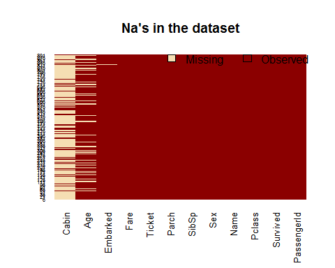

```r
missmap(data,y.cex=0.5,main="Na's in the dataset")
```

- Make this plot prettier with `ggplot2` and help from [neato package’s function](https://github.com/njtierney/neato/blob/master/R/ggplot_missing.R)

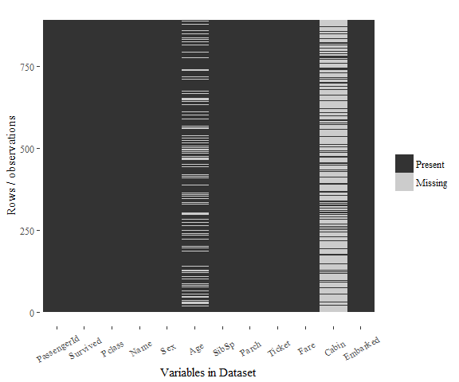

```r
ggplot_missing <- function(x){

  x %>%
    is.na %>%
    melt %>%
    ggplot(data = .,
           aes(x = Var2,
               y = Var1)) +
    geom_raster(aes(fill = value)) +
    scale_fill_grey(name = "",
                    labels = c("Present","Missing")) +
    theme_tufte() +
    theme(axis.text.x  = element_text(angle=30, vjust=0.5)) +
    labs(x = "Variables in Dataset",
         y = "Rows / observations")
  }
ggplot_missing(data)
```

## 3.1 Explore and extract info from Name variable

```r
head(data$Name)
```

```
## [1] Braund, Mr. Owen Harris
## [2] Cumings, Mrs. John Bradley (Florence Briggs Thayer)
## [3] Heikkinen, Miss. Laina
## [4] Futrelle, Mrs. Jacques Heath (Lily May Peel)
## [5] Allen, Mr. William Henry
## [6] Moran, Mr. James
## 891 Levels: Abbing, Mr. Anthony ... Zimmerman, Mr. Leo
```

```r
# sort(data$Name) # I sorted alphabetically so I could understand better. You can se
# Now lets make some new variables
data=separate(data,col=Name,into=c('Surname',"temp"),sep =c(', '),remove=F)
data=separate(data,col=temp,into="Title",sep ='. ',remove=TRUE)
# After a while, I compared the results with others and i had one mistake. I did not take into account if the title is more than one word. So, I lost 'the Countess' and got just 'th'. So watch out!
#data$Title <- gsub('(.*, )|(\\..*)', '', data$Name)
#data$Surame=sapply(as.character(data$Name),function(x) unlist(strsplit(x, split = '[,.]'))[1])
summary(factor(data$Title))
```

```
##     Capt      Col      Don       Dr Jonkheer     Lady    Major   Master
##        1        2        1        7        1        1        2       40
##     Miss     Mlle      Mme       Mr      Mrs       Ms      Rev      Sir
##      182        2        1      517      125        1        6        1
##       th
##        1
```

```r
data[,c(5,6)]
```

|  | Surname | Title |
| --- | --- | --- |
| 1 | Braund | Mr |
| 2 | Cumings | Mrs |
| 3 | Heikkinen | Miss |
| 4 | Futrelle | Mrs |
| 5 | Allen | Mr |
| 6 | Moran | Mr |
| 7 | McCarthy | Mr |
| 8 | Palsson | Master |
| 9 | Johnson | Mrs |
| 10 | Nasser | Mrs |

[output cut: 881 more lines]

```r
other_title <- c('Dona', 'Lady', 'th','Capt', 'Col', 'Don',
                'Dr', 'Major', 'Rev', 'Sir', 'Jonkheer')

data$Title[data$Title == 'Mlle']        <- 'Miss'
data$Title[data$Title == 'Ms']          <- 'Miss'
data$Title[data$Title == 'Mme']         <- 'Mrs'
data$Title[data$Title %in% other_title]  <- 'Other Title'
table(data$Sex,data$Title)
```

```
##
##          Master Miss  Mr Mrs Other Title
##   female      0  185   0 126           3
##   male       40    0 517   0          20
```

- Let’s see the Surnames. There are printed the names that appear more than one time in the dataset. I ll use them later (this report is in progress). The table also shows how many names appeared 1 time, how many two times etc.

```r
n=data.frame(table(data$Surname))
reg_names=data[rownames(n[n$Freq > 1,]),]
SurnameNum=data.frame(table(sort(n$Freq)))
names(SurnameNum)=c("# of times the Surname appears","# of names")
options(xtable.comment = FALSE)

xtable(SurnameNum)
```

|  | # of times the Surname appears | # of names |
| --- | --- | --- |
| 1 | 1 | 534 |
| 2 | 2 | 83 |
| 3 | 3 | 28 |
| 4 | 4 | 14 |
| 5 | 5 | 1 |
| 6 | 6 | 5 |
| 7 | 7 | 1 |
| 8 | 9 | 1 |

```r
sort(reg_names[,5]) # these are the names that appear more than one time in the dataset
```

```
##   [1] "Abelson"                "Allison"
##   [3] "Anderson"               "Andersson"
##   [5] "Andersson"              "Andrews"
##   [7] "Arnold-Franchi"         "Asplund"
##   [9] "Asplund"                "Asplund"
##  [11] "Backstrom"              "Baclini"
##  [13] "Baclini"                "Barber"
##  [15] "Baxter"                 "Bengtsson"
##  [17] "Berglund"               "Bissette"
##  [19] "Bjornstrom-Steffansson" "Bonnell"
##  [21] "Bowerman"               "Braund"
##  [23] "Butt"                   "Calic"
##  [25] "Carbines"               "Celotti"
##  [27] "Chronopoulos"           "Cor"
##  [29] "Coutts"                 "Crease"
```

[output cut: 52 more lines]

## 3.2 Imput the Na’s of Age variable

- I run a regression model on Age. (Note that the variable Embarked has two Na’s which lm() omits)
- Then predict the Na’s, see if the imputation left the Age variable distribution without significan change

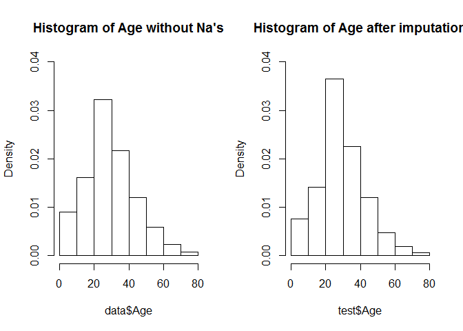

```r
set.seed(123)
m=lm(Age~.,data=data[,-c(1,4,5,11,9,10,13)]) # regression
t=predict(m,data[is.na(data$Age),-c(1,4,5,11,9,10,13,8)]) # predict na's from regression model
# Remove any negative value and replace it with 0.5
for(i in 1:length(t)){
  if(t[i]<0) {
      t[i]= 0.5
  }
}

# Lets test now
test=data
test[names(t),8]=t
par(mfrow=c(1,2))
hist(data$Age,freq=F,ylim = c(0,0.04),main="Histogram of Age without Na's")
hist(test$Age,freq=F,ylim = c(0,0.04),main="Histogram of Age after imputation")
```

```r
# Since it seems ok
data[names(t),8]=t
dim(data)
```

```
## [1] 891  14
```

```r
summary(is.na(data$Age)) ## DONE!
```

```
##    Mode   FALSE
## logical     891
```

- At the end, the Age variable has no Na’s. That’s nice, though a better job could definitely be done.

## 3.3 Fix the two Na’s in Embarked

At this point I got a little bored so I ll just remove those two observations

```r
data=data[!is.na(data$Embarked),]
dim(data)
```

```
## [1] 889  14
```

# 4 Some nice Visualization

## 4.1 Densities

- Fare: Found something interesting. There are 15 observations with zero fare. That doesnt seems right so let’s examine further:

```r
zeroFare=data[data$Fare==0,]
#ggplot(data,
 #      aes(x=log10(Fare)))+
 # geom_density(fill="blue",
 #              alpha=0.3)+
 # theme_excel()
options(xtable.comment = FALSE)
xtable(summary(zeroFare))
```

|  | PassengerId | Survived | Pclass | Name | Surname | Title | Sex | Age | SibSp | Parch | Ticket | Fare | Cabin | Embarked |
| --- | --- | --- | --- | --- | --- | --- | --- | --- | --- | --- | --- | --- | --- | --- |
| 1 | Min. :180.0 | Min. :0.00000 | Min. :1.000 | Andrews, Mr. Thomas Jr :1 | Length:15 | Length:15 | female: 0 | Min. :19.00 | Min. :0 | Min. :0 | LINE :4 | Min. :0 | A36 : 1 | : 0 |
| 2 | 1st Qu.:290.5 | 1st Qu.:0.00000 | 1st Qu.:1.000 | Campbell, Mr. William :1 | Class :character | Class :character | male :15 | 1st Qu.:35.78 | 1st Qu.:0 | 1st Qu.:0 | 239853 :3 | 1st Qu.:0 | B102 : 1 | C: 0 |
| 3 | Median :482.0 | Median :0.00000 | Median :2.000 | Cunningham, Mr. Alfred Fleming :1 | Mode :character | Mode :character | NA | Median :35.78 | Median :0 | Median :0 | 112050 :1 | Median :0 | B94 : 1 | Q: 0 |
| 4 | Mean :516.4 | Mean :0.06667 | Mean :1.933 | Frost, Mr. Anthony Wood "Archie":1 | NA | NA | NA | Mean :36.42 | Mean :0 | Mean :0 | 112052 :1 | Mean :0 | : 0 | S:15 |
| 5 | 3rd Qu.:704.0 | 3rd Qu.:0.00000 | 3rd Qu.:2.500 | Fry, Mr. Richard :1 | NA | NA | NA | 3rd Qu.:39.50 | 3rd Qu.:0 | 3rd Qu.:0 | 112058 :1 | 3rd Qu.:0 | A10 : 0 | NA |
| 6 | Max. :823.0 | Max. :1.00000 | Max. :3.000 | Harrison, Mr. William :1 | NA | NA | NA | Max. :49.00 | Max. :0 | Max. :0 | 112059 :1 | Max. :0 | (Other): 0 | NA |
| 7 | NA | NA | NA | (Other) :9 | NA | NA | NA | NA | NA | NA | (Other):4 | NA | NA's :12 | NA |

- From summary, we can see that they all are males adults bettween 19 and 49, all embarked from Southampton alone(without any family member) and all have ticket numbers. Let’s see the rest characteristics.

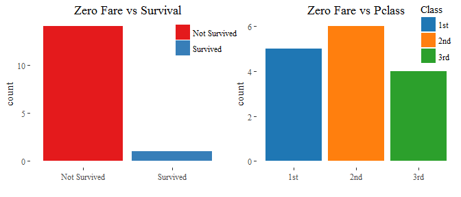

```r
g1= ggplot(zeroFare,
        aes(x=factor(Survived),fill=factor(Survived)))+
    geom_bar()+
    scale_x_discrete(breaks=c(0,1),
                     labels=c("Not Survived","Survived"),
                     name=" ")+
    scale_fill_brewer(palette="Set1",breaks=c(0,1),
                     labels=c("Not Survived","Survived"),
                     name=" ")+
    theme_tufte()+
    theme(legend.position = c(0.9,0.9),
          plot.title = element_text(hjust=0.5))+
    ggtitle("Zero Fare vs Survival")


g2= ggplot(zeroFare,
        aes(x=factor(Pclass),fill=factor(Pclass)))+
    geom_bar()+
    scale_fill_tableau(name="Class",
                       breaks=c(1,2,3),
                       labels=c("1st","2nd","3rd"))+
    scale_x_discrete(name="",
                     breaks=c(1,2,3),
                     labels=c("1st","2nd","3rd"))+
    theme_tufte()+
    theme(legend.position = c(0.9,0.9),
          plot.title = element_text(hjust=0.5))+
    ggtitle("Zero Fare vs Pclass")

multiplot(g1,g2,cols = 2)
```

- Only one of them Survived. I consider these zero values as missing and I ll handle them as Na’s.

## 4.2 Survived

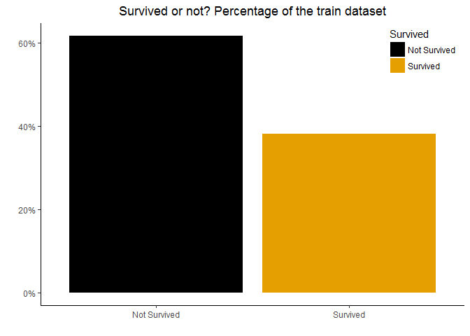

```r
ggplot(data,
       aes(x=factor(Survived)))+
  geom_bar(
       aes(y=(..count../sum(..count..)),
           fill=factor(Survived)))+
  scale_x_discrete(breaks=c(0,1),
                   labels=c("Not Survived","Survived"),name=" ")+
  scale_fill_colorblind(breaks=c(0,1),
                   labels=c("Not Survived","Survived"),name="Survived")+
  scale_y_continuous(breaks = c(0,0.2,0.4,0.6),
                     labels=c("0%","20%","40%","60%"))+
  theme_classic()+
  theme(plot.title = element_text(hjust=0.5),
        legend.position = c(0.9,0.9))+
  ggtitle('Survived or not? Percentage of the train dataset')+
  ylab(" ")
```

## 4.3 Sex

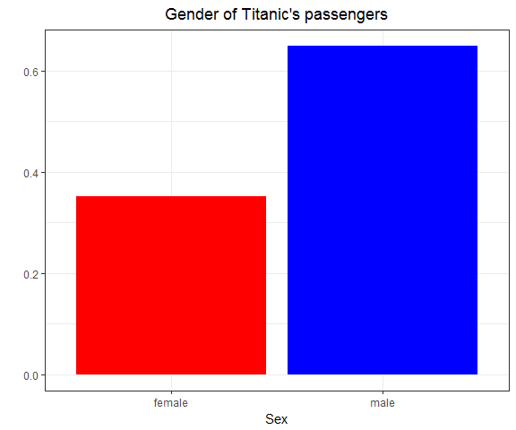

```r
ggplot(data,
       aes(Sex)
       )+
  geom_bar(
    aes(y=(..count..)/sum(..count..)),  # returns the percentage instead of the count, for just count = ..count..
    fill=c('red','blue')  # choose your colours
    )+
  ylab('')+
  ggtitle("Gender of Titanic's passengers")+
  theme_bw()+
  theme(plot.title = element_text(hjust = 0.5)) # centers the main title
```

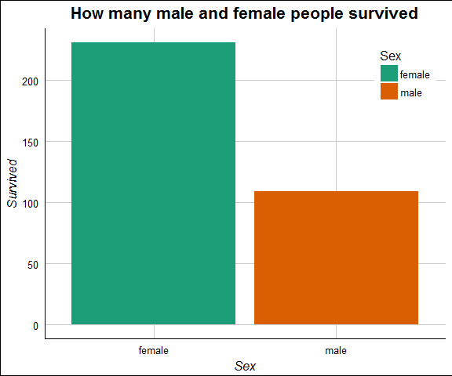

```r
ggplot(data,
       aes(y=Survived,
           x=Sex,
           fill=as.factor(Sex)
           )
       )+
  geom_bar(stat = 'identity'
           )+
  scale_fill_brewer(palette='Dark2', # RcolorBrewer package
                    name='Sex'  # title for the legend
                    )+
  theme_gdocs(base_size = 12 # font size for the gdocs theme from ggthemes package
              )+
  theme(legend.position = c(0.9, .85), # choose the exact position for the legend in your graph
        plot.title = element_text(hjust = 0.5) # centers the main title of the plot
        )+
  ggtitle('How many male and female people survived')
```

## 4.4 Age

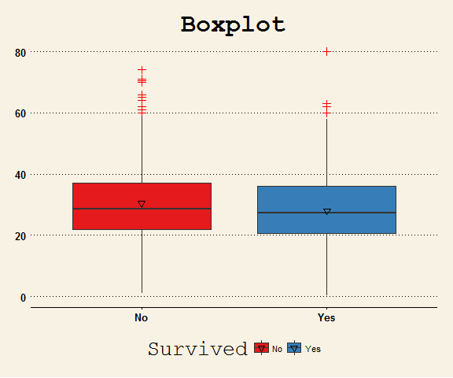

```r
ggplot(na.omit(data[,c(2,8)]),
       aes(x=factor(Survived),
           y=Age,
           fill=factor(Survived))
       )+
  geom_boxplot(outlier.colour = "red",  # how to show the outliers in the plot
               outlier.shape = 3, #outlier shape
               outlier.size = 2  # outlier size
               )+
  stat_summary(fun.y = mean,   # visualize the mean in the boxplot to get an idea about the data distribution
               geom = "point", # type of the mean icon
               shape = 6,       # shape of the mean icon
               size = 2       # size
               )+
  theme_wsj(base_size = 10   # size of the font in wall street journal theme
            )+
  ggtitle("Boxplot")+
  xlab('Survived')+
  theme(legend.position = 'bottom', # theme() options overrides the wsj theme options
        plot.title = element_text(hjust = 0.5) # centers the title
        )+
  scale_fill_brewer(palette = 'Set1',
                    name="Survived",
                    breaks=c(0,1),
                    labels=c("No", "Yes")
                    )+
  scale_x_discrete(breaks=c(0,1),
                   labels=c("No", "Yes")
                   )
```

## 4.5 Economic class, Fare and Embarked

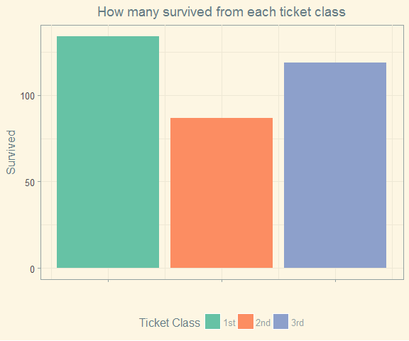

```r
ggplot(data,
       aes(x=Pclass,
           y=Survived,
           fill=factor(Pclass))
       )+
  geom_bar(stat="identity")+
  theme_solarized()+ # nice theme from ggthemes
  scale_fill_brewer(palette="Set2",
                    name="Ticket Class",
                    breaks=c(1,2,3),
                    labels=c("1st","2nd","3rd")
                    )+
  theme(legend.position = 'bottom',
         axis.text.x = element_blank(), # No text on x axis
        plot.title = element_text(hjust = 0.5)
        )+
  xlab("")+
  ggtitle('How many survived from each ticket class')
```

```r
g1=ggplot(data,
          aes(x=factor(Survived),y=Fare)
          )+
  geom_boxplot()+
  theme_minimal()+
  theme(axis.title.x = element_blank()
        )
## There are extreme values that destroy the plot..Let's remove:
g2=ggplot(data,
          aes(x=factor(Survived),y=Fare)
          )+
  geom_boxplot()+
  scale_y_continuous(limits = c(0, 300)
                     )+
  theme_excel()+
  theme(axis.title.x = element_blank()
        )+
  ylab('')
## The plot shows 1 extreme value over 300 but three values are excluded.
tail(sort(data$Fare))
```

```
## [1] 263.0000 263.0000 263.0000 512.3292 512.3292 512.3292
```

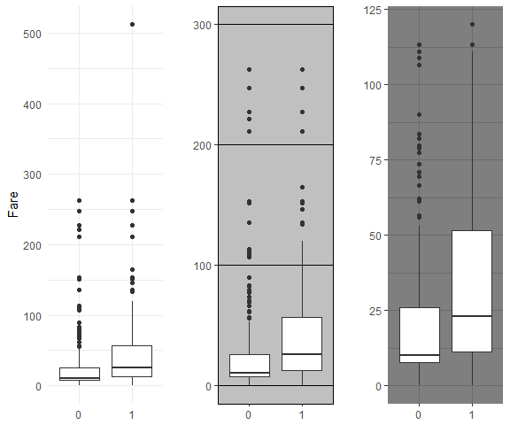

It seems that the survivers had paid significant higher fare by mean, even though we have many extreme values and outliers. It should be pointed out that the three passengers with the much higher fare all survived

```r
## and thats correct because three tickets had the biggest and the same fare.
g3=ggplot(data,
          aes(x=factor(Survived),y=Fare)
          )+
  geom_boxplot()+
  scale_y_continuous(limits = c(0, 120))+
  theme_dark()+
  theme(axis.title.x = element_blank()
        )+
  ylab('')
multiplot(g1,g2,g3,cols=3)
```

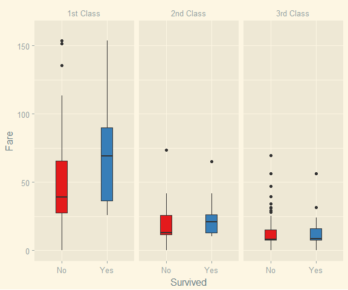

This plot gives a slightly different view. In the 2nd and 3rd class there seems to be no significant difference. In the 1st class thought it seems that the people who paid higher fare survived by mean.

```r
ggplot(data,
       aes(x=factor(Survived),
           y=Fare,
           fill=factor(Survived)))+
  geom_boxplot()+
  facet_grid(~Pclass,
             labeller=labeller(Pclass = c('1'="1st Class",'2'="2nd Class",'3'="3rd Class")) # change the facet's labels
             )+
  theme_solarized_2()+
  scale_y_continuous(limits = c(0,160)   # manipulate the y-axis limits to omit some extreme values
                     )+
  xlab("Survived")+
  scale_fill_brewer(palette = 'Set1',guide=FALSE   # guide=F to remove legend
                    )+
  scale_x_discrete(breaks=c(0,1),labels=c("No","Yes")) # change the names of x axis. You have to define the breaks and then give labels
```

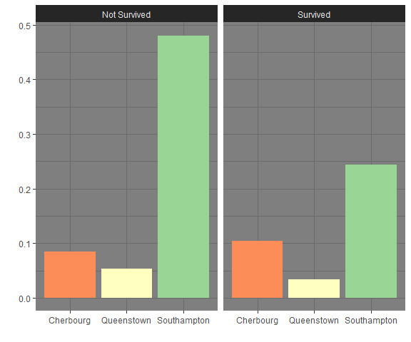

```r
ggplot(data[!is.na(data$Embarked),],aes(x=Embarked,
                y=(..count..)/sum(..count..),fill=Embarked))+
  geom_bar()+
  facet_grid(~Survived,
             labeller = labeller(Survived=c('0'="Not Survived",'1'="Survived")))+
  scale_fill_brewer(palette = "Spectral",guide=F)+
  theme_dark()+ylab('')+xlab("")+
  scale_x_discrete(breaks=c("C","Q","S"),
                   labels=c("Cherbourg","Queenstown","Southampton"))
```

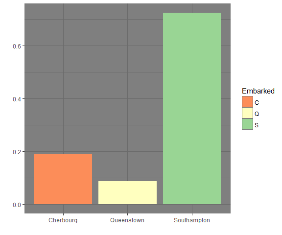

```r
ggplot(data[!is.na(data$Embarked),],aes(x=Embarked,
                y=(..count..)/sum(..count..),fill=Embarked))+
  geom_bar()+
  scale_fill_brewer(palette = "Spectral")+
  theme_dark()+ylab('')+xlab("")+
  scale_x_discrete(breaks=c("C","Q","S"),
                   labels=c("Cherbourg","Queenstown","Southampton"))
```

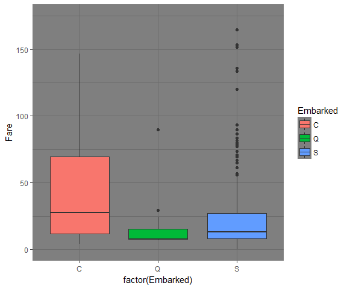

```r
ggplot(data[!is.na(data$Embarked),],aes(x=factor(Embarked),
                y=Fare,fill=Embarked))+
  theme_dark()+
  geom_boxplot()+scale_y_continuous(limits = c(0,175))
```

## 4.6 Andrews plot

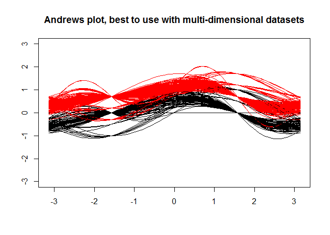

Andrews plot is useful for multidimensional datasets. We can see if the groups of the Survived variable are seperatable with the (numerical) variables of this dataset.

```r
test<-data[,-c(1,4,5,9,10,11)]  # I exclude all the none numerical variables, not the Survived though
test<-na.omit(test) # no missing values for the andrews plot..
andrews(test, # data
        clr=1, # the variable I want to use to color the strings
        type =1, ymax=3,step=80,main="Andrews plot, best to use with multi-dimensional datasets")
```

## 4.7 Calculate the Family Size

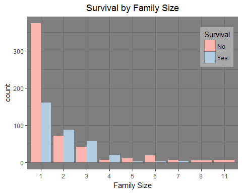

```r
data$FamSize=data$SibSp+data$Parch+1

ggplot(data,
       aes(x=factor(FamSize),
           fill=factor(Survived))
       )+
  geom_bar(stat='count',position='dodge')+
  scale_fill_brewer(palette="Pastel1",name="Survival",
                    breaks=c(0,1),labels=c("No","Yes"))+
  theme_dark()+xlab("Family Size")+
  ggtitle("Survival by Family Size")+
  scale_x_discrete(breaks=c(1:11),labels=c(1:11))+
  theme( plot.title = element_text(hjust = 0.5),legend.position = c(0.9,0.8),legend.background = element_rect(fill = 'darkgrey'))
```

# 5 Models

## 5.1 Train and test sets.

We could much more to learn about titanic and its passengers but lets built a simple model.

- I create 1000 samples from the data. Every time I sample with replacement 889 observations from the dataset to create a training set. The observations that did not get selected are forming the test dataset. So the every training set has 889 observations and the test set around 35% of 889.
- I train my model 1000 times and I get the accuracy for each time. Now I now the mean accuracy and the standard deviation.

```r
mdata=select(data,c(Survived,Pclass,Sex,Title,Age,Fare,Embarked,FamSize,SibSp,Parch)) # select variables
mdata$Survived=factor(mdata$Survived,
                      levels = 0:1,
                      labels = c("no", "yes"))

test$Pclass=as.numeric(test$Pclass)



accuracy=NULL
for(i in 1:1000){
  te=sample(1:889,889,replace = TRUE)
  train=mdata[te,]
  test=mdata[-te,]
  model=glm(Survived~.,train,family = 'binomial')
  p=round(predict(model,test[,-1],type="response"))
  accuracy[i]=sum(diag(table(p,test[,1])))/sum(table(p,test[,1]))
}
mean(accuracy)
```

```
## [1] 0.8248693
```

```r
sd(accuracy)
```

```
## [1] 0.01734939
```